# Diversity and distribution of socially parasitic ants

Kyle W. Gray & Christian Rabeling

February 27, 2019

#### Here, we give the total number of socially parasitic species and genera that harbor social parasites based on an extensive literature search, then show the taxonomic and biogeographical distribution of socially parasitic strategies.

## Number of social parasite species and genera

The total number of social parasite species is **350** but this includes numerous undescribed species where parasitic strategy has not been inferred (species of *Pheidole* and *Tetraponera*). The number of species where parasitic strategy has been inferred based on morphology or phylogentic position is **340**.

The distribution of species across parasitic strategies is as follows:

| Form of parasitism | Count |
| --- | --- |
| Dulosis | 78 |
| Inquilinism | 96 |
| Temporary | 166 |

The number of genera that harbor social parasites is **42**.

## Taxonomic distribution of social parasites

Next, let’s look at the distribution of social parasities across the six subfamilies that harbor social parasites.

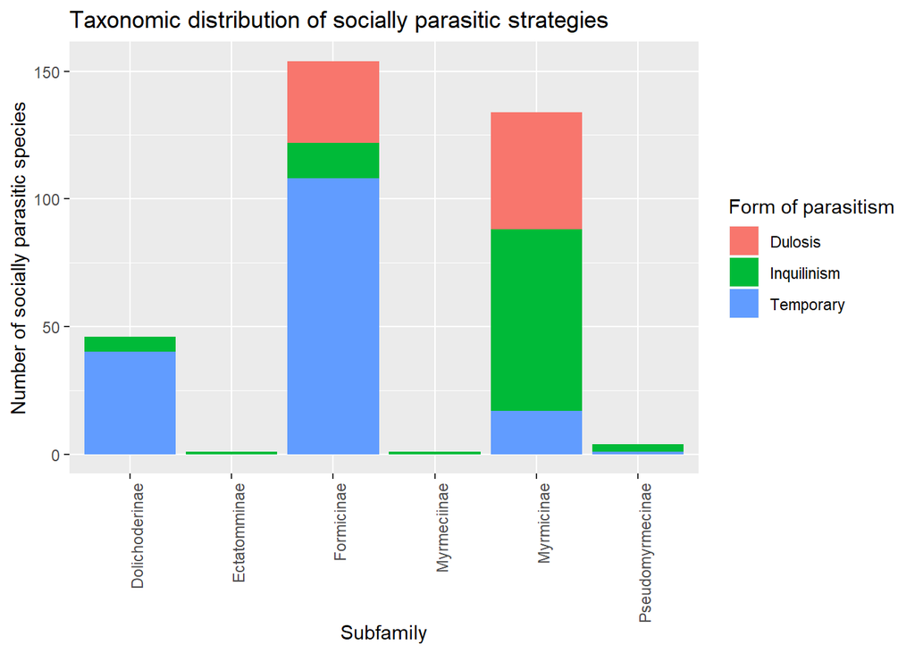

In table format:

| Subfamily | Form of parasitism | Count |
| --- | --- | --- |
| Dolichoderinae | Inquilinism | 6 |
| Dolichoderinae | Temporary | 40 |
| Ectatomminae | Inquilinism | 1 |
| Formicinae | Dulosis | 32 |
| Formicinae | Inquilinism | 14 |
| Formicinae | Temporary | 108 |
| Myrmeciinae | Inquilinism | 1 |
| Myrmicinae | Dulosis | 46 |
| Myrmicinae | Inquilinism | 71 |
| Myrmicinae | Temporary | 17 |
| Pseudomyrmecinae | Inquilinism | 3 |
| Pseudomyrmecinae | Temporary | 1 |

Now, let’s look at the distribution of subfamilies within each parasitic strategy.

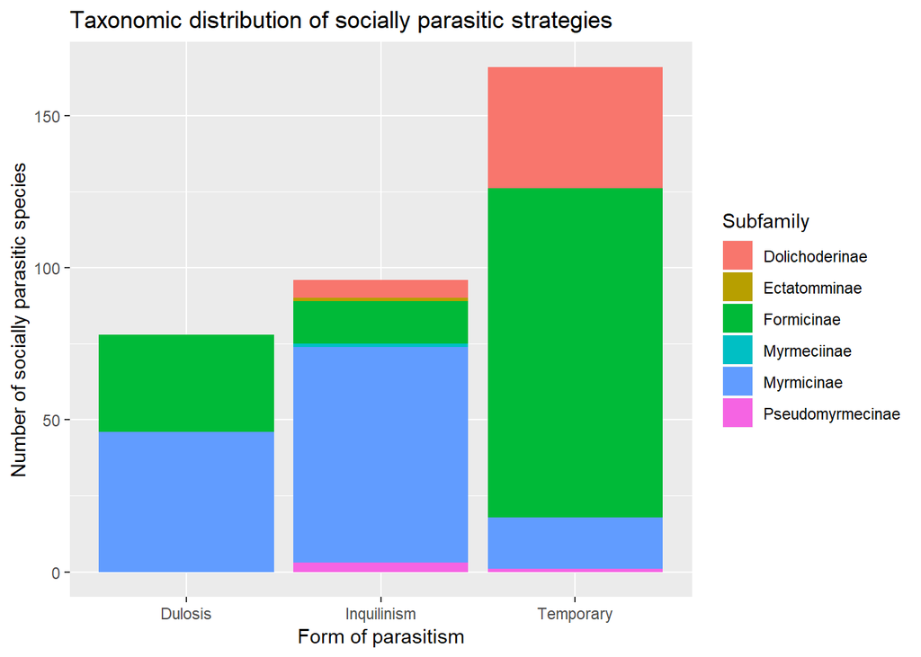

In table format:

| Form of parasitism | Subfamily | Count |
| --- | --- | --- |
| Dulosis | Formicinae | 32 |
| Dulosis | Myrmicinae | 46 |
| Inquilinism | Dolichoderinae | 6 |
| Inquilinism | Ectatomminae | 1 |
| Inquilinism | Formicinae | 14 |
| Inquilinism | Myrmeciinae | 1 |
| Inquilinism | Myrmicinae | 71 |
| Inquilinism | Pseudomyrmecinae | 3 |
| Temporary | Dolichoderinae | 40 |
| Temporary | Formicinae | 108 |
| Temporary | Myrmicinae | 17 |
| Temporary | Pseudomyrmecinae | 1 |

## Biogeographic distribution of social parasites

Let’s look at the distribution of socially parasitic ant species across biogeographic regions.

> Notice, the total number of social parasite species across bioregions will be higher than the total species from eariler counts because some species occupy two bioregions. Nonetheless, these species are rare and do no impact the overall distribution pattern of social parasites across bioregions.

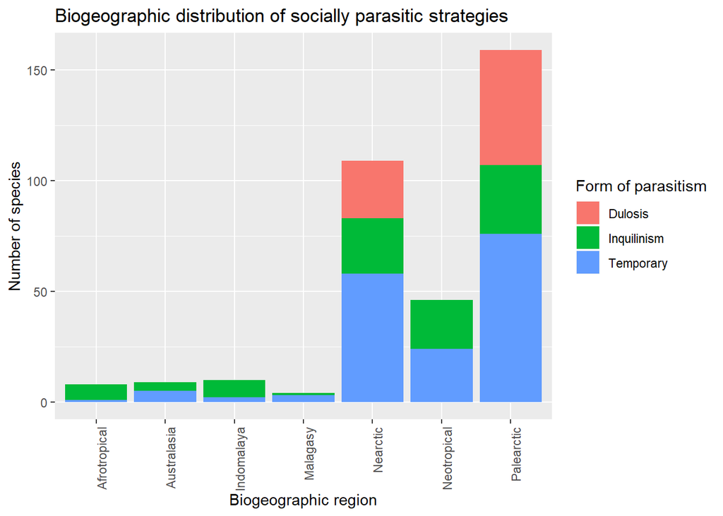

In table format:

| Bioregion | Form of parasitism | Count |
| --- | --- | --- |
| Afrotropical | Inquilinism | 7 |
| Afrotropical | Temporary | 1 |
| Australasia | Inquilinism | 4 |
| Australasia | Temporary | 5 |
| Indomalaya | Inquilinism | 8 |
| Indomalaya | Temporary | 2 |
| Malagasy | Inquilinism | 1 |
| Malagasy | Temporary | 3 |
| Nearctic | Dulosis | 26 |
| Nearctic | Inquilinism | 25 |
| Nearctic | Temporary | 58 |
| Neotropical | Inquilinism | 22 |
| Neotropical | Temporary | 24 |
| Palearctic | Dulosis | 52 |
| Palearctic | Inquilinism | 31 |
| Palearctic | Temporary | 76 |